# Risk Factor Analysis

## Outcome Variable

**Outcome Variable:** wast_rec90d

## Predictor Variables

**Intervention Variable:** mage

**Adjustment Set:**

unadjusted

## Stratifying Variables

The analysis was stratified on these variable(s):

- agecat
- studyid
- country

## Data Summary

| agecat | studyid | country | mage | wast_rec90d | n_cell | n |
| --- | --- | --- | --- | --- | --- | --- |
| 0-24 months | ki0047075b-MAL-ED | BANGLADESH | [20-30) | 0 | 24 | 124 |
| 0-24 months | ki0047075b-MAL-ED | BANGLADESH | [20-30) | 1 | 46 | 124 |
| 0-24 months | ki0047075b-MAL-ED | BANGLADESH | <20 | 0 | 8 | 124 |
| 0-24 months | ki0047075b-MAL-ED | BANGLADESH | <20 | 1 | 17 | 124 |
| 0-24 months | ki0047075b-MAL-ED | BANGLADESH | >=30 | 0 | 13 | 124 |
| 0-24 months | ki0047075b-MAL-ED | BANGLADESH | >=30 | 1 | 16 | 124 |
| 0-24 months | ki0047075b-MAL-ED | BRAZIL | [20-30) | 0 | 3 | 23 |
| 0-24 months | ki0047075b-MAL-ED | BRAZIL | [20-30) | 1 | 11 | 23 |
| 0-24 months | ki0047075b-MAL-ED | BRAZIL | <20 | 0 | 0 | 23 |
| 0-24 months | ki0047075b-MAL-ED | BRAZIL | <20 | 1 | 4 | 23 |
| 0-24 months | ki0047075b-MAL-ED | BRAZIL | >=30 | 0 | 3 | 23 |
| 0-24 months | ki0047075b-MAL-ED | BRAZIL | >=30 | 1 | 2 | 23 |
| 0-24 months | ki0047075b-MAL-ED | INDIA | [20-30) | 0 | 58 | 177 |
| 0-24 months | ki0047075b-MAL-ED | INDIA | [20-30) | 1 | 84 | 177 |
| 0-24 months | ki0047075b-MAL-ED | INDIA | <20 | 0 | 12 | 177 |
| 0-24 months | ki0047075b-MAL-ED | INDIA | <20 | 1 | 16 | 177 |
| 0-24 months | ki0047075b-MAL-ED | INDIA | >=30 | 0 | 1 | 177 |
| 0-24 months | ki0047075b-MAL-ED | INDIA | >=30 | 1 | 6 | 177 |
| 0-24 months | ki0047075b-MAL-ED | NEPAL | [20-30) | 0 | 18 | 93 |
| 0-24 months | ki0047075b-MAL-ED | NEPAL | [20-30) | 1 | 59 | 93 |
| 0-24 months | ki0047075b-MAL-ED | NEPAL | <20 | 0 | 1 | 93 |
| 0-24 months | ki0047075b-MAL-ED | NEPAL | <20 | 1 | 2 | 93 |
| 0-24 months | ki0047075b-MAL-ED | NEPAL | >=30 | 0 | 1 | 93 |
| 0-24 months | ki0047075b-MAL-ED | NEPAL | >=30 | 1 | 12 | 93 |
| 0-24 months | ki0047075b-MAL-ED | PERU | [20-30) | 0 | 3 | 34 |
| 0-24 months | ki0047075b-MAL-ED | PERU | [20-30) | 1 | 14 | 34 |
| 0-24 months | ki0047075b-MAL-ED | PERU | <20 | 0 | 2 | 34 |
| 0-24 months | ki0047075b-MAL-ED | PERU | <20 | 1 | 9 | 34 |
| 0-24 months | ki0047075b-MAL-ED | PERU | >=30 | 0 | 1 | 34 |
| 0-24 months | ki0047075b-MAL-ED | PERU | >=30 | 1 | 5 | 34 |

[output cut: 450 more lines]

The following strata were considered:

- agecat: 0-24 months, studyid: ki0047075b-MAL-ED, country: BANGLADESH
- agecat: 0-24 months, studyid: ki0047075b-MAL-ED, country: BRAZIL
- agecat: 0-24 months, studyid: ki0047075b-MAL-ED, country: INDIA
- agecat: 0-24 months, studyid: ki0047075b-MAL-ED, country: NEPAL
- agecat: 0-24 months, studyid: ki0047075b-MAL-ED, country: PERU
- agecat: 0-24 months, studyid: ki0047075b-MAL-ED, country: SOUTH AFRICA
- agecat: 0-24 months, studyid: ki0047075b-MAL-ED, country: TANZANIA, UNITED REPUBLIC OF
- agecat: 0-24 months, studyid: ki1000108-CMC-V-BCS-2002, country: INDIA
- agecat: 0-24 months, studyid: ki1000108-IRC, country: INDIA
- agecat: 0-24 months, studyid: ki1000109-EE, country: PAKISTAN
- agecat: 0-24 months, studyid: ki1000304b-SAS-CompFeed, country: INDIA
- agecat: 0-24 months, studyid: ki1000304b-SAS-FoodSuppl, country: INDIA
- agecat: 0-24 months, studyid: ki1017093-NIH-Birth, country: BANGLADESH
- agecat: 0-24 months, studyid: ki1017093b-PROVIDE, country: BANGLADESH
- agecat: 0-24 months, studyid: ki1017093c-NIH-Crypto, country: BANGLADESH
- agecat: 0-24 months, studyid: ki1066203-TanzaniaChild2, country: TANZANIA, UNITED REPUBLIC OF
- agecat: 0-24 months, studyid: ki1101329-Keneba, country: GAMBIA
- agecat: 0-24 months, studyid: ki1112895-Guatemala BSC, country: GUATEMALA
- agecat: 0-24 months, studyid: ki1112895-iLiNS-Zinc, country: BURKINA FASO
- agecat: 0-24 months, studyid: ki1113344-GMS-Nepal, country: NEPAL
- agecat: 0-24 months, studyid: ki1119695-PROBIT, country: BELARUS
- agecat: 0-24 months, studyid: ki1126311-ZVITAMBO, country: ZIMBABWE
- agecat: 0-24 months, studyid: ki1135781-COHORTS, country: GUATEMALA
- agecat: 0-24 months, studyid: ki1135781-COHORTS, country: INDIA
- agecat: 0-24 months, studyid: ki1135781-COHORTS, country: PHILIPPINES
- agecat: 0-24 months, studyid: ki1148112-LCNI-5, country: MALAWI
- agecat: 0-24 months, studyid: kiGH5241-JiVitA-3, country: BANGLADESH
- agecat: 0-6 months, studyid: ki0047075b-MAL-ED, country: BANGLADESH
- agecat: 0-6 months, studyid: ki0047075b-MAL-ED, country: BRAZIL
- agecat: 0-6 months, studyid: ki0047075b-MAL-ED, country: INDIA
- agecat: 0-6 months, studyid: ki0047075b-MAL-ED, country: NEPAL
- agecat: 0-6 months, studyid: ki0047075b-MAL-ED, country: PERU
- agecat: 0-6 months, studyid: ki0047075b-MAL-ED, country: SOUTH AFRICA
- agecat: 0-6 months, studyid: ki0047075b-MAL-ED, country: TANZANIA, UNITED REPUBLIC OF
- agecat: 0-6 months, studyid: ki1000108-CMC-V-BCS-2002, country: INDIA
- agecat: 0-6 months, studyid: ki1000108-IRC, country: INDIA
- agecat: 0-6 months, studyid: ki1000109-EE, country: PAKISTAN
- agecat: 0-6 months, studyid: ki1000304b-SAS-CompFeed, country: INDIA
- agecat: 0-6 months, studyid: ki1000304b-SAS-FoodSuppl, country: INDIA
- agecat: 0-6 months, studyid: ki1017093-NIH-Birth, country: BANGLADESH
- agecat: 0-6 months, studyid: ki1017093b-PROVIDE, country: BANGLADESH
- agecat: 0-6 months, studyid: ki1017093c-NIH-Crypto, country: BANGLADESH
- agecat: 0-6 months, studyid: ki1066203-TanzaniaChild2, country: TANZANIA, UNITED REPUBLIC OF
- agecat: 0-6 months, studyid: ki1101329-Keneba, country: GAMBIA
- agecat: 0-6 months, studyid: ki1112895-Guatemala BSC, country: GUATEMALA
- agecat: 0-6 months, studyid: ki1113344-GMS-Nepal, country: NEPAL
- agecat: 0-6 months, studyid: ki1119695-PROBIT, country: BELARUS
- agecat: 0-6 months, studyid: ki1126311-ZVITAMBO, country: ZIMBABWE
- agecat: 0-6 months, studyid: ki1135781-COHORTS, country: GUATEMALA
- agecat: 0-6 months, studyid: ki1135781-COHORTS, country: INDIA
- agecat: 0-6 months, studyid: ki1135781-COHORTS, country: PHILIPPINES
- agecat: 0-6 months, studyid: ki1148112-LCNI-5, country: MALAWI
- agecat: 0-6 months, studyid: kiGH5241-JiVitA-3, country: BANGLADESH
- agecat: 6-24 months, studyid: ki0047075b-MAL-ED, country: BANGLADESH
- agecat: 6-24 months, studyid: ki0047075b-MAL-ED, country: BRAZIL
- agecat: 6-24 months, studyid: ki0047075b-MAL-ED, country: INDIA
- agecat: 6-24 months, studyid: ki0047075b-MAL-ED, country: NEPAL
- agecat: 6-24 months, studyid: ki0047075b-MAL-ED, country: PERU
- agecat: 6-24 months, studyid: ki0047075b-MAL-ED, country: SOUTH AFRICA
- agecat: 6-24 months, studyid: ki0047075b-MAL-ED, country: TANZANIA, UNITED REPUBLIC OF
- agecat: 6-24 months, studyid: ki1000108-CMC-V-BCS-2002, country: INDIA
- agecat: 6-24 months, studyid: ki1000108-IRC, country: INDIA
- agecat: 6-24 months, studyid: ki1000109-EE, country: PAKISTAN
- agecat: 6-24 months, studyid: ki1000304b-SAS-CompFeed, country: INDIA
- agecat: 6-24 months, studyid: ki1000304b-SAS-FoodSuppl, country: INDIA
- agecat: 6-24 months, studyid: ki1017093-NIH-Birth, country: BANGLADESH
- agecat: 6-24 months, studyid: ki1017093b-PROVIDE, country: BANGLADESH
- agecat: 6-24 months, studyid: ki1017093c-NIH-Crypto, country: BANGLADESH
- agecat: 6-24 months, studyid: ki1066203-TanzaniaChild2, country: TANZANIA, UNITED REPUBLIC OF
- agecat: 6-24 months, studyid: ki1101329-Keneba, country: GAMBIA
- agecat: 6-24 months, studyid: ki1112895-Guatemala BSC, country: GUATEMALA
- agecat: 6-24 months, studyid: ki1112895-iLiNS-Zinc, country: BURKINA FASO
- agecat: 6-24 months, studyid: ki1113344-GMS-Nepal, country: NEPAL
- agecat: 6-24 months, studyid: ki1119695-PROBIT, country: BELARUS
- agecat: 6-24 months, studyid: ki1126311-ZVITAMBO, country: ZIMBABWE
- agecat: 6-24 months, studyid: ki1135781-COHORTS, country: GUATEMALA
- agecat: 6-24 months, studyid: ki1135781-COHORTS, country: INDIA
- agecat: 6-24 months, studyid: ki1135781-COHORTS, country: PHILIPPINES
- agecat: 6-24 months, studyid: ki1148112-LCNI-5, country: MALAWI
- agecat: 6-24 months, studyid: kiGH5241-JiVitA-3, country: BANGLADESH

### Dropped Strata

Some strata were dropped due to rare outcomes:

- agecat: 0-24 months, studyid: ki0047075b-MAL-ED, country: BRAZIL
- agecat: 0-24 months, studyid: ki0047075b-MAL-ED, country: INDIA
- agecat: 0-24 months, studyid: ki0047075b-MAL-ED, country: NEPAL
- agecat: 0-24 months, studyid: ki0047075b-MAL-ED, country: PERU
- agecat: 0-24 months, studyid: ki0047075b-MAL-ED, country: SOUTH AFRICA
- agecat: 0-24 months, studyid: ki0047075b-MAL-ED, country: TANZANIA, UNITED REPUBLIC OF
- agecat: 0-24 months, studyid: ki1000109-EE, country: PAKISTAN
- agecat: 0-24 months, studyid: ki1000304b-SAS-FoodSuppl, country: INDIA
- agecat: 0-24 months, studyid: ki1112895-Guatemala BSC, country: GUATEMALA
- agecat: 0-24 months, studyid: ki1112895-iLiNS-Zinc, country: BURKINA FASO
- agecat: 0-24 months, studyid: ki1148112-LCNI-5, country: MALAWI
- agecat: 0-6 months, studyid: ki0047075b-MAL-ED, country: BANGLADESH
- agecat: 0-6 months, studyid: ki0047075b-MAL-ED, country: BRAZIL
- agecat: 0-6 months, studyid: ki0047075b-MAL-ED, country: INDIA
- agecat: 0-6 months, studyid: ki0047075b-MAL-ED, country: NEPAL
- agecat: 0-6 months, studyid: ki0047075b-MAL-ED, country: PERU
- agecat: 0-6 months, studyid: ki0047075b-MAL-ED, country: SOUTH AFRICA
- agecat: 0-6 months, studyid: ki0047075b-MAL-ED, country: TANZANIA, UNITED REPUBLIC OF
- agecat: 0-6 months, studyid: ki1000108-CMC-V-BCS-2002, country: INDIA
- agecat: 0-6 months, studyid: ki1000109-EE, country: PAKISTAN
- agecat: 0-6 months, studyid: ki1000304b-SAS-FoodSuppl, country: INDIA
- agecat: 0-6 months, studyid: ki1017093b-PROVIDE, country: BANGLADESH
- agecat: 0-6 months, studyid: ki1017093c-NIH-Crypto, country: BANGLADESH
- agecat: 0-6 months, studyid: ki1112895-Guatemala BSC, country: GUATEMALA
- agecat: 0-6 months, studyid: ki1148112-LCNI-5, country: MALAWI
- agecat: 6-24 months, studyid: ki0047075b-MAL-ED, country: BRAZIL
- agecat: 6-24 months, studyid: ki0047075b-MAL-ED, country: INDIA
- agecat: 6-24 months, studyid: ki0047075b-MAL-ED, country: NEPAL
- agecat: 6-24 months, studyid: ki0047075b-MAL-ED, country: PERU
- agecat: 6-24 months, studyid: ki0047075b-MAL-ED, country: SOUTH AFRICA
- agecat: 6-24 months, studyid: ki0047075b-MAL-ED, country: TANZANIA, UNITED REPUBLIC OF
- agecat: 6-24 months, studyid: ki1000108-CMC-V-BCS-2002, country: INDIA
- agecat: 6-24 months, studyid: ki1000108-IRC, country: INDIA
- agecat: 6-24 months, studyid: ki1000109-EE, country: PAKISTAN
- agecat: 6-24 months, studyid: ki1000304b-SAS-CompFeed, country: INDIA
- agecat: 6-24 months, studyid: ki1000304b-SAS-FoodSuppl, country: INDIA
- agecat: 6-24 months, studyid: ki1017093-NIH-Birth, country: BANGLADESH
- agecat: 6-24 months, studyid: ki1017093c-NIH-Crypto, country: BANGLADESH
- agecat: 6-24 months, studyid: ki1112895-Guatemala BSC, country: GUATEMALA
- agecat: 6-24 months, studyid: ki1112895-iLiNS-Zinc, country: BURKINA FASO
- agecat: 6-24 months, studyid: ki1119695-PROBIT, country: BELARUS
- agecat: 6-24 months, studyid: ki1135781-COHORTS, country: GUATEMALA
- agecat: 6-24 months, studyid: ki1135781-COHORTS, country: INDIA
- agecat: 6-24 months, studyid: ki1148112-LCNI-5, country: MALAWI
- agecat: 6-24 months, studyid: kiGH5241-JiVitA-3, country: BANGLADESH

## Methods Detail

We’re interested in the causal parameters $E[Y_a]$ for all values of $a \in \mathcal{A}$. These parameters represent the mean outcome if, possibly contrary to fact, we intervened to set all units to have $A=a$. Under the randomization and positivity assumptions, these are identified by the statistical parameters $\psi_a=E_W[E_{Y|A,W}(Y|A=a,W)]$. In addition, we’re interested in the mean of $Y$, $E[Y]$ under no intervention (the observed mean). We will estimate these parameters by using SuperLearner to fit the relevant likelihood factors – $E_{Y|A,W}(Y|A=a,W)$ and $p(A=a|W)$, and then updating our likelihood fit using a joint TMLE.

For unadjusted analyses ($W=\{\}$), initial likelihoods were estimated using Lrnr_glm to estimate the simple $E(Y|A)$ and Lrnr_mean to estimate $p(A)$. For adjusted analyses, a small library containing Lrnr_glmnet, Lrnr_xgboost, and Lrnr_mean was used.

Having estimated these parameters, we will then use the delta method to estimate relative risks and attributable risks relative to a prespecified baseline level of $A$.

# Results Detail

## Results Plots

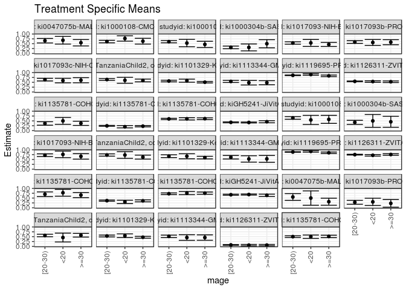

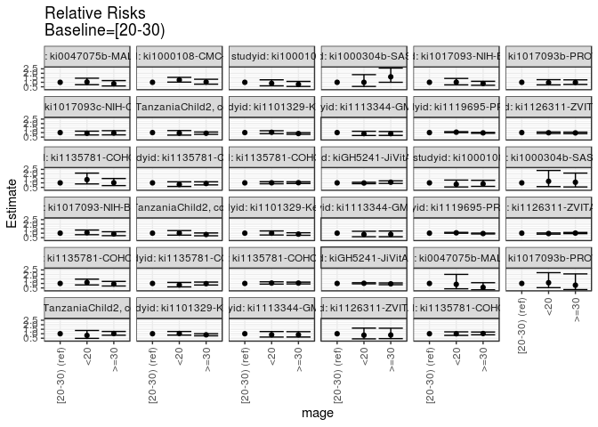

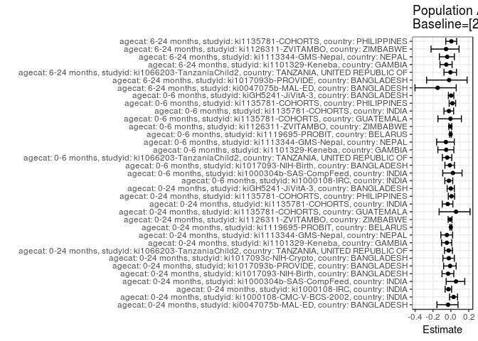

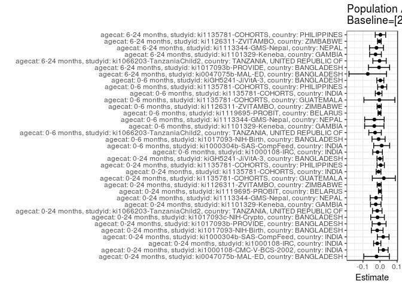

## Results Table

### Parameter: TSM

| agecat | studyid | country | intervention_level | baseline_level | estimate | ci_lower | ci_upper |
| --- | --- | --- | --- | --- | --- | --- | --- |
| 0-24 months | ki0047075b-MAL-ED | BANGLADESH | [20-30) | NA | 0.6571429 | 0.5406898 | 0.7735959 |
| 0-24 months | ki0047075b-MAL-ED | BANGLADESH | <20 | NA | 0.6800000 | 0.4819438 | 0.8780562 |
| 0-24 months | ki0047075b-MAL-ED | BANGLADESH | >=30 | NA | 0.5517241 | 0.3870228 | 0.7164254 |
| 0-24 months | ki1000108-CMC-V-BCS-2002 | INDIA | [20-30) | NA | 0.6126482 | 0.5473590 | 0.6779374 |
| 0-24 months | ki1000108-CMC-V-BCS-2002 | INDIA | <20 | NA | 0.7714286 | 0.6335453 | 0.9093119 |
| 0-24 months | ki1000108-CMC-V-BCS-2002 | INDIA | >=30 | NA | 0.6315789 | 0.4821442 | 0.7810137 |
| 0-24 months | ki1000108-IRC | INDIA | [20-30) | NA | 0.6059701 | 0.5489040 | 0.6630363 |
| 0-24 months | ki1000108-IRC | INDIA | <20 | NA | 0.5333333 | 0.3421602 | 0.7245064 |
| 0-24 months | ki1000108-IRC | INDIA | >=30 | NA | 0.4666667 | 0.3071858 | 0.6261475 |
| 0-24 months | ki1000304b-SAS-CompFeed | INDIA | [20-30) | NA | 0.3105263 | 0.2427000 | 0.3783526 |
| 0-24 months | ki1000304b-SAS-CompFeed | INDIA | <20 | NA | 0.3103448 | 0.1313149 | 0.4893748 |
| 0-24 months | ki1000304b-SAS-CompFeed | INDIA | >=30 | NA | 0.5000000 | 0.2896540 | 0.7103460 |
| 0-24 months | ki1017093-NIH-Birth | BANGLADESH | [20-30) | NA | 0.5365854 | 0.4751640 | 0.5980067 |
| 0-24 months | ki1017093-NIH-Birth | BANGLADESH | <20 | NA | 0.5428571 | 0.3658374 | 0.7198769 |
| 0-24 months | ki1017093-NIH-Birth | BANGLADESH | >=30 | NA | 0.4639175 | 0.3608362 | 0.5669988 |
| 0-24 months | ki1017093b-PROVIDE | BANGLADESH | [20-30) | NA | 0.5882353 | 0.5193144 | 0.6571562 |
| 0-24 months | ki1017093b-PROVIDE | BANGLADESH | <20 | NA | 0.5652174 | 0.4114854 | 0.7189494 |
| 0-24 months | ki1017093b-PROVIDE | BANGLADESH | >=30 | NA | 0.5789474 | 0.4473137 | 0.7105810 |
| 0-24 months | ki1017093c-NIH-Crypto | BANGLADESH | [20-30) | NA | 0.6381910 | 0.5696412 | 0.7067407 |
| 0-24 months | ki1017093c-NIH-Crypto | BANGLADESH | <20 | NA | 0.5901639 | 0.4724894 | 0.7078385 |
| 0-24 months | ki1017093c-NIH-Crypto | BANGLADESH | >=30 | NA | 0.6078431 | 0.4757701 | 0.7399162 |
| 0-24 months | ki1066203-TanzaniaChild2 | TANZANIA, UNITED REPUBLIC OF | [20-30) | NA | 0.6428571 | 0.5964647 | 0.6892496 |
| 0-24 months | ki1066203-TanzaniaChild2 | TANZANIA, UNITED REPUBLIC OF | <20 | NA | 0.6041667 | 0.4499991 | 0.7583342 |
| 0-24 months | ki1066203-TanzaniaChild2 | TANZANIA, UNITED REPUBLIC OF | >=30 | NA | 0.5950000 | 0.5240251 | 0.6659749 |
| 0-24 months | ki1101329-Keneba | GAMBIA | [20-30) | NA | 0.5663189 | 0.5242599 | 0.6083779 |
| 0-24 months | ki1101329-Keneba | GAMBIA | <20 | NA | 0.5847953 | 0.5045894 | 0.6650013 |
| 0-24 months | ki1101329-Keneba | GAMBIA | >=30 | NA | 0.5059524 | 0.4659723 | 0.5459325 |
| 0-24 months | ki1113344-GMS-Nepal | NEPAL | [20-30) | NA | 0.5454545 | 0.4914859 | 0.5994232 |
| 0-24 months | ki1113344-GMS-Nepal | NEPAL | <20 | NA | 0.4803922 | 0.3637569 | 0.5970274 |
| 0-24 months | ki1113344-GMS-Nepal | NEPAL | >=30 | NA | 0.4791667 | 0.3722690 | 0.5860643 |

[output cut: 75 more lines]

### Parameter: E(Y)

| agecat | studyid | country | intervention_level | baseline_level | estimate | ci_lower | ci_upper |
| --- | --- | --- | --- | --- | --- | --- | --- |
| 0-24 months | ki0047075b-MAL-ED | BANGLADESH | NA | NA | 0.6370968 | 0.5511492 | 0.7230443 |
| 0-24 months | ki1000108-CMC-V-BCS-2002 | INDIA | NA | NA | 0.6319018 | 0.5759256 | 0.6878781 |
| 0-24 months | ki1000108-IRC | INDIA | NA | NA | 0.5898734 | 0.5376978 | 0.6420491 |
| 0-24 months | ki1000304b-SAS-CompFeed | INDIA | NA | NA | 0.3292181 | 0.2676535 | 0.3907827 |
| 0-24 months | ki1017093-NIH-Birth | BANGLADESH | NA | NA | 0.5202864 | 0.4695109 | 0.5710618 |
| 0-24 months | ki1017093b-PROVIDE | BANGLADESH | NA | NA | 0.5830619 | 0.5262762 | 0.6398476 |
| 0-24 months | ki1017093c-NIH-Crypto | BANGLADESH | NA | NA | 0.6237942 | 0.5698223 | 0.6777662 |
| 0-24 months | ki1066203-TanzaniaChild2 | TANZANIA, UNITED REPUBLIC OF | NA | NA | 0.6267606 | 0.5890263 | 0.6644948 |
| 0-24 months | ki1101329-Keneba | GAMBIA | NA | NA | 0.5416116 | 0.5143001 | 0.5689232 |
| 0-24 months | ki1113344-GMS-Nepal | NEPAL | NA | NA | 0.5222816 | 0.4773852 | 0.5671781 |
| 0-24 months | ki1119695-PROBIT | BELARUS | NA | NA | 0.8616295 | 0.8472386 | 0.8760204 |
| 0-24 months | ki1126311-ZVITAMBO | ZIMBABWE | NA | NA | 0.5442043 | 0.5277100 | 0.5606986 |
| 0-24 months | ki1135781-COHORTS | GUATEMALA | NA | NA | 0.3907563 | 0.3259495 | 0.4555631 |
| 0-24 months | ki1135781-COHORTS | INDIA | NA | NA | 0.2355670 | 0.2165976 | 0.2545364 |
| 0-24 months | ki1135781-COHORTS | PHILIPPINES | NA | NA | 0.6068680 | 0.5823645 | 0.6313715 |
| 0-24 months | kiGH5241-JiVitA-3 | BANGLADESH | NA | NA | 0.4247718 | 0.4091425 | 0.4404012 |
| 0-6 months | ki1000108-IRC | INDIA | NA | NA | 0.6375000 | 0.5751450 | 0.6998550 |
| 0-6 months | ki1000304b-SAS-CompFeed | INDIA | NA | NA | 0.4351852 | 0.3405027 | 0.5298677 |
| 0-6 months | ki1017093-NIH-Birth | BANGLADESH | NA | NA | 0.7130045 | 0.6535890 | 0.7724200 |
| 0-6 months | ki1066203-TanzaniaChild2 | TANZANIA, UNITED REPUBLIC OF | NA | NA | 0.7020649 | 0.6526590 | 0.7514708 |
| 0-6 months | ki1101329-Keneba | GAMBIA | NA | NA | 0.6352657 | 0.5887450 | 0.6817864 |
| 0-6 months | ki1113344-GMS-Nepal | NEPAL | NA | NA | 0.5833333 | 0.5108676 | 0.6557991 |
| 0-6 months | ki1119695-PROBIT | BELARUS | NA | NA | 0.8822149 | 0.8684104 | 0.8960194 |
| 0-6 months | ki1126311-ZVITAMBO | ZIMBABWE | NA | NA | 0.7443159 | 0.7272505 | 0.7613813 |
| 0-6 months | ki1135781-COHORTS | GUATEMALA | NA | NA | 0.6929134 | 0.6123695 | 0.7734573 |
| 0-6 months | ki1135781-COHORTS | INDIA | NA | NA | 0.3581505 | 0.3318331 | 0.3844678 |
| 0-6 months | ki1135781-COHORTS | PHILIPPINES | NA | NA | 0.7367021 | 0.7051294 | 0.7682749 |
| 0-6 months | kiGH5241-JiVitA-3 | BANGLADESH | NA | NA | 0.6725846 | 0.6538934 | 0.6912758 |
| 6-24 months | ki0047075b-MAL-ED | BANGLADESH | NA | NA | 0.4838710 | 0.3544124 | 0.6133295 |
| 6-24 months | ki1017093b-PROVIDE | BANGLADESH | NA | NA | 0.2764228 | 0.1950773 | 0.3577682 |
| 6-24 months | ki1066203-TanzaniaChild2 | TANZANIA, UNITED REPUBLIC OF | NA | NA | 0.5579515 | 0.5056058 | 0.6102972 |
| 6-24 months | ki1101329-Keneba | GAMBIA | NA | NA | 0.5063636 | 0.4748679 | 0.5378594 |
| 6-24 months | ki1113344-GMS-Nepal | NEPAL | NA | NA | 0.4934383 | 0.4388573 | 0.5480193 |
| 6-24 months | ki1126311-ZVITAMBO | ZIMBABWE | NA | NA | 0.0691288 | 0.0539734 | 0.0842842 |
| 6-24 months | ki1135781-COHORTS | PHILIPPINES | NA | NA | 0.5026681 | 0.4688378 | 0.5364984 |

### Parameter: RR

| agecat | studyid | country | intervention_level | baseline_level | estimate | ci_lower | ci_upper |
| --- | --- | --- | --- | --- | --- | --- | --- |
| 0-24 months | ki0047075b-MAL-ED | BANGLADESH | [20-30) | [20-30) | 1.0000000 | 1.0000000 | 1.0000000 |
| 0-24 months | ki0047075b-MAL-ED | BANGLADESH | <20 | [20-30) | 1.0347826 | 0.7358140 | 1.4552251 |
| 0-24 months | ki0047075b-MAL-ED | BANGLADESH | >=30 | [20-30) | 0.8395802 | 0.5929854 | 1.1887221 |
| 0-24 months | ki1000108-CMC-V-BCS-2002 | INDIA | [20-30) | [20-30) | 1.0000000 | 1.0000000 | 1.0000000 |
| 0-24 months | ki1000108-CMC-V-BCS-2002 | INDIA | <20 | [20-30) | 1.2591705 | 1.0225845 | 1.5504933 |
| 0-24 months | ki1000108-CMC-V-BCS-2002 | INDIA | >=30 | [20-30) | 1.0308998 | 0.7952710 | 1.3363426 |
| 0-24 months | ki1000108-IRC | INDIA | [20-30) | [20-30) | 1.0000000 | 1.0000000 | 1.0000000 |
| 0-24 months | ki1000108-IRC | INDIA | <20 | [20-30) | 0.8801314 | 0.6075574 | 1.2749927 |
| 0-24 months | ki1000108-IRC | INDIA | >=30 | [20-30) | 0.7701149 | 0.5402651 | 1.0977519 |
| 0-24 months | ki1000304b-SAS-CompFeed | INDIA | [20-30) | [20-30) | 1.0000000 | 1.0000000 | 1.0000000 |
| 0-24 months | ki1000304b-SAS-CompFeed | INDIA | <20 | [20-30) | 0.9994155 | 0.5392911 | 1.8521192 |
| 0-24 months | ki1000304b-SAS-CompFeed | INDIA | >=30 | [20-30) | 1.6101695 | 1.0023267 | 2.5866275 |
| 0-24 months | ki1017093-NIH-Birth | BANGLADESH | [20-30) | [20-30) | 1.0000000 | 1.0000000 | 1.0000000 |
| 0-24 months | ki1017093-NIH-Birth | BANGLADESH | <20 | [20-30) | 1.0116883 | 0.7161022 | 1.4292838 |
| 0-24 months | ki1017093-NIH-Birth | BANGLADESH | >=30 | [20-30) | 0.8645736 | 0.6733556 | 1.1100932 |
| 0-24 months | ki1017093b-PROVIDE | BANGLADESH | [20-30) | [20-30) | 1.0000000 | 1.0000000 | 1.0000000 |
| 0-24 months | ki1017093b-PROVIDE | BANGLADESH | <20 | [20-30) | 0.9608696 | 0.7145234 | 1.2921485 |
| 0-24 months | ki1017093b-PROVIDE | BANGLADESH | >=30 | [20-30) | 0.9842105 | 0.7620102 | 1.2712039 |
| 0-24 months | ki1017093c-NIH-Crypto | BANGLADESH | [20-30) | [20-30) | 1.0000000 | 1.0000000 | 1.0000000 |
| 0-24 months | ki1017093c-NIH-Crypto | BANGLADESH | <20 | [20-30) | 0.9247451 | 0.7370681 | 1.1602096 |
| 0-24 months | ki1017093c-NIH-Crypto | BANGLADESH | >=30 | [20-30) | 0.9524471 | 0.7472406 | 1.2140073 |
| 0-24 months | ki1066203-TanzaniaChild2 | TANZANIA, UNITED REPUBLIC OF | [20-30) | [20-30) | 1.0000000 | 1.0000000 | 1.0000000 |
| 0-24 months | ki1066203-TanzaniaChild2 | TANZANIA, UNITED REPUBLIC OF | <20 | [20-30) | 0.9398148 | 0.7208988 | 1.2252093 |
| 0-24 months | ki1066203-TanzaniaChild2 | TANZANIA, UNITED REPUBLIC OF | >=30 | [20-30) | 0.9255556 | 0.8051072 | 1.0640236 |
| 0-24 months | ki1101329-Keneba | GAMBIA | [20-30) | [20-30) | 1.0000000 | 1.0000000 | 1.0000000 |
| 0-24 months | ki1101329-Keneba | GAMBIA | <20 | [20-30) | 1.0326254 | 0.8834684 | 1.2069648 |
| 0-24 months | ki1101329-Keneba | GAMBIA | >=30 | [20-30) | 0.8934054 | 0.8015784 | 0.9957519 |
| 0-24 months | ki1113344-GMS-Nepal | NEPAL | [20-30) | [20-30) | 1.0000000 | 1.0000000 | 1.0000000 |
| 0-24 months | ki1113344-GMS-Nepal | NEPAL | <20 | [20-30) | 0.8807190 | 0.6775966 | 1.1447311 |
| 0-24 months | ki1113344-GMS-Nepal | NEPAL | >=30 | [20-30) | 0.8784722 | 0.6881861 | 1.1213732 |

[output cut: 75 more lines]

### Parameter: PAR

| agecat | studyid | country | intervention_level | baseline_level | estimate | ci_lower | ci_upper |
| --- | --- | --- | --- | --- | --- | --- | --- |
| 0-24 months | ki0047075b-MAL-ED | BANGLADESH | [20-30) | NA | -0.0200461 | -0.0951000 | 0.0550079 |
| 0-24 months | ki1000108-CMC-V-BCS-2002 | INDIA | [20-30) | NA | 0.0192536 | -0.0087860 | 0.0472932 |
| 0-24 months | ki1000108-IRC | INDIA | [20-30) | NA | -0.0160967 | -0.0373720 | 0.0051786 |
| 0-24 months | ki1000304b-SAS-CompFeed | INDIA | [20-30) | NA | 0.0186918 | -0.0156495 | 0.0530331 |
| 0-24 months | ki1017093-NIH-Birth | BANGLADESH | [20-30) | NA | -0.0162990 | -0.0504996 | 0.0179016 |
| 0-24 months | ki1017093b-PROVIDE | BANGLADESH | [20-30) | NA | -0.0051734 | -0.0459401 | 0.0355933 |
| 0-24 months | ki1017093c-NIH-Crypto | BANGLADESH | [20-30) | NA | -0.0143967 | -0.0544249 | 0.0256314 |
| 0-24 months | ki1066203-TanzaniaChild2 | TANZANIA, UNITED REPUBLIC OF | [20-30) | NA | -0.0160966 | -0.0439482 | 0.0117550 |
| 0-24 months | ki1101329-Keneba | GAMBIA | [20-30) | NA | -0.0247073 | -0.0555534 | 0.0061388 |
| 0-24 months | ki1113344-GMS-Nepal | NEPAL | [20-30) | NA | -0.0231729 | -0.0573401 | 0.0109943 |
| 0-24 months | ki1119695-PROBIT | BELARUS | [20-30) | NA | -0.0004823 | -0.0092602 | 0.0082956 |
| 0-24 months | ki1126311-ZVITAMBO | ZIMBABWE | [20-30) | NA | -0.0048236 | -0.0165901 | 0.0069430 |
| 0-24 months | ki1135781-COHORTS | GUATEMALA | [20-30) | NA | 0.0223352 | -0.0450285 | 0.0896990 |
| 0-24 months | ki1135781-COHORTS | INDIA | [20-30) | NA | -0.0083748 | -0.0223883 | 0.0056387 |
| 0-24 months | ki1135781-COHORTS | PHILIPPINES | [20-30) | NA | 0.0041426 | -0.0172129 | 0.0254981 |
| 0-24 months | kiGH5241-JiVitA-3 | BANGLADESH | [20-30) | NA | -0.0002570 | -0.0174574 | 0.0169434 |
| 0-6 months | ki1000108-IRC | INDIA | [20-30) | NA | -0.0142413 | -0.0424320 | 0.0139495 |
| 0-6 months | ki1000304b-SAS-CompFeed | INDIA | [20-30) | NA | 0.0098978 | -0.0369617 | 0.0567573 |
| 0-6 months | ki1017093-NIH-Birth | BANGLADESH | [20-30) | NA | -0.0085145 | -0.0467921 | 0.0297631 |
| 0-6 months | ki1066203-TanzaniaChild2 | TANZANIA, UNITED REPUBLIC OF | [20-30) | NA | -0.0288768 | -0.0655418 | 0.0077881 |
| 0-6 months | ki1101329-Keneba | GAMBIA | [20-30) | NA | -0.0334090 | -0.0900331 | 0.0232152 |
| 0-6 months | ki1113344-GMS-Nepal | NEPAL | [20-30) | NA | -0.0327381 | -0.0898898 | 0.0244136 |
| 0-6 months | ki1119695-PROBIT | BELARUS | [20-30) | NA | -0.0028942 | -0.0114207 | 0.0056323 |
| 0-6 months | ki1126311-ZVITAMBO | ZIMBABWE | [20-30) | NA | -0.0047837 | -0.0169789 | 0.0074115 |
| 0-6 months | ki1135781-COHORTS | GUATEMALA | [20-30) | NA | -0.0035152 | -0.0941453 | 0.0871149 |
| 0-6 months | ki1135781-COHORTS | INDIA | [20-30) | NA | -0.0079101 | -0.0272917 | 0.0114714 |
| 0-6 months | ki1135781-COHORTS | PHILIPPINES | [20-30) | NA | 0.0129578 | -0.0135854 | 0.0395011 |
| 0-6 months | kiGH5241-JiVitA-3 | BANGLADESH | [20-30) | NA | 0.0019750 | -0.0185398 | 0.0224898 |
| 6-24 months | ki0047075b-MAL-ED | BANGLADESH | [20-30) | NA | -0.0716846 | -0.1816278 | 0.0382586 |
| 6-24 months | ki1017093b-PROVIDE | BANGLADESH | [20-30) | NA | -0.0056285 | -0.0676577 | 0.0564006 |
| 6-24 months | ki1066203-TanzaniaChild2 | TANZANIA, UNITED REPUBLIC OF | [20-30) | NA | -0.0027180 | -0.0417530 | 0.0363171 |
| 6-24 months | ki1101329-Keneba | GAMBIA | [20-30) | NA | -0.0263096 | -0.0605775 | 0.0079583 |
| 6-24 months | ki1113344-GMS-Nepal | NEPAL | [20-30) | NA | -0.0205059 | -0.0614904 | 0.0204786 |
| 6-24 months | ki1126311-ZVITAMBO | ZIMBABWE | [20-30) | NA | -0.0037284 | -0.0144942 | 0.0070375 |
| 6-24 months | ki1135781-COHORTS | PHILIPPINES | [20-30) | NA | 0.0026681 | -0.0278732 | 0.0332093 |

### Parameter: PAF

| agecat | studyid | country | intervention_level | baseline_level | estimate | ci_lower | ci_upper |
| --- | --- | --- | --- | --- | --- | --- | --- |
| 0-24 months | ki0047075b-MAL-ED | BANGLADESH | [20-30) | NA | -0.0314647 | -0.1561481 | 0.0797723 |
| 0-24 months | ki1000108-CMC-V-BCS-2002 | INDIA | [20-30) | NA | 0.0304693 | -0.0153283 | 0.0742012 |
| 0-24 months | ki1000108-IRC | INDIA | [20-30) | NA | -0.0272885 | -0.0639884 | 0.0081456 |
| 0-24 months | ki1000304b-SAS-CompFeed | INDIA | [20-30) | NA | 0.0567763 | -0.0530896 | 0.1551802 |
| 0-24 months | ki1017093-NIH-Birth | BANGLADESH | [20-30) | NA | -0.0313269 | -0.0992537 | 0.0324024 |
| 0-24 months | ki1017093b-PROVIDE | BANGLADESH | [20-30) | NA | -0.0088728 | -0.0813039 | 0.0587064 |
| 0-24 months | ki1017093c-NIH-Crypto | BANGLADESH | [20-30) | NA | -0.0230793 | -0.0892459 | 0.0390680 |
| 0-24 months | ki1066203-TanzaniaChild2 | TANZANIA, UNITED REPUBLIC OF | [20-30) | NA | -0.0256822 | -0.0711606 | 0.0178654 |
| 0-24 months | ki1101329-Keneba | GAMBIA | [20-30) | NA | -0.0456181 | -0.1040959 | 0.0097625 |
| 0-24 months | ki1113344-GMS-Nepal | NEPAL | [20-30) | NA | -0.0443686 | -0.1123549 | 0.0194625 |
| 0-24 months | ki1119695-PROBIT | BELARUS | [20-30) | NA | -0.0005598 | -0.0107995 | 0.0095763 |
| 0-24 months | ki1126311-ZVITAMBO | ZIMBABWE | [20-30) | NA | -0.0088635 | -0.0307226 | 0.0125320 |
| 0-24 months | ki1135781-COHORTS | GUATEMALA | [20-30) | NA | 0.0571590 | -0.1314119 | 0.2143011 |
| 0-24 months | ki1135781-COHORTS | INDIA | [20-30) | NA | -0.0355518 | -0.0966517 | 0.0221439 |
| 0-24 months | ki1135781-COHORTS | PHILIPPINES | [20-30) | NA | 0.0068262 | -0.0290128 | 0.0414170 |
| 0-24 months | kiGH5241-JiVitA-3 | BANGLADESH | [20-30) | NA | -0.0006050 | -0.0419289 | 0.0390799 |
| 0-6 months | ki1000108-IRC | INDIA | [20-30) | NA | -0.0223393 | -0.0676463 | 0.0210451 |
| 0-6 months | ki1000304b-SAS-CompFeed | INDIA | [20-30) | NA | 0.0227439 | -0.0911466 | 0.1247470 |
| 0-6 months | ki1017093-NIH-Birth | BANGLADESH | [20-30) | NA | -0.0119417 | -0.0670961 | 0.0403619 |
| 0-6 months | ki1066203-TanzaniaChild2 | TANZANIA, UNITED REPUBLIC OF | [20-30) | NA | -0.0411313 | -0.0950270 | 0.0101118 |
| 0-6 months | ki1101329-Keneba | GAMBIA | [20-30) | NA | -0.0525906 | -0.1457821 | 0.0330212 |
| 0-6 months | ki1113344-GMS-Nepal | NEPAL | [20-30) | NA | -0.0561224 | -0.1594095 | 0.0379632 |
| 0-6 months | ki1119695-PROBIT | BELARUS | [20-30) | NA | -0.0032806 | -0.0129941 | 0.0063398 |
| 0-6 months | ki1126311-ZVITAMBO | ZIMBABWE | [20-30) | NA | -0.0064270 | -0.0229487 | 0.0098279 |
| 0-6 months | ki1135781-COHORTS | GUATEMALA | [20-30) | NA | -0.0050731 | -0.1447663 | 0.1175737 |
| 0-6 months | ki1135781-COHORTS | INDIA | [20-30) | NA | -0.0220861 | -0.0776635 | 0.0306251 |
| 0-6 months | ki1135781-COHORTS | PHILIPPINES | [20-30) | NA | 0.0175890 | -0.0191519 | 0.0530053 |
| 0-6 months | kiGH5241-JiVitA-3 | BANGLADESH | [20-30) | NA | 0.0029364 | -0.0280368 | 0.0329765 |
| 6-24 months | ki0047075b-MAL-ED | BANGLADESH | [20-30) | NA | -0.1481481 | -0.4017062 | 0.0595432 |
| 6-24 months | ki1017093b-PROVIDE | BANGLADESH | [20-30) | NA | -0.0203620 | -0.2715476 | 0.1812036 |
| 6-24 months | ki1066203-TanzaniaChild2 | TANZANIA, UNITED REPUBLIC OF | [20-30) | NA | -0.0048713 | -0.0773326 | 0.0627161 |
| 6-24 months | ki1101329-Keneba | GAMBIA | [20-30) | NA | -0.0519580 | -0.1219355 | 0.0136549 |
| 6-24 months | ki1113344-GMS-Nepal | NEPAL | [20-30) | NA | -0.0415572 | -0.1287095 | 0.0388657 |
| 6-24 months | ki1126311-ZVITAMBO | ZIMBABWE | [20-30) | NA | -0.0539335 | -0.2221172 | 0.0911054 |
| 6-24 months | ki1135781-COHORTS | PHILIPPINES | [20-30) | NA | 0.0053079 | -0.0573475 | 0.0642505 |